| [*Home*](https://antonio-catalano.github.io/) | [*About*](https://antonio-catalano.github.io/about.html) | [*Archive*](https://antonio-catalano.github.io/Archive.html) |  |
| --- | --- | --- | --- |

# Automated monitoring of the current weights of a portfolio

```python
import matplotlib.pyplot as plt, numpy as np, pandas as pd
plt.style.use('bmh')
from matplotlib import rcParams
rcParams['font.family'] = 'Verdana'
```

Let's suppose that 3 months ago we built our portfolio with this macro asset allocation:  
35% equity - 50% bonds - 15% precious metals

Let's suppose that after 2 months stock prices have fallen and precious metals prices have risen, mantaining the value of portfolio close to the initial capital of 100k, but with different weights. Moreover the relative weights of the asset within each macro asset have changed (for example the weight of gold is not anymore the same within the precious metals class, or the weight of equity emerging markets has changed compared to the initial weight).

We want to know which are the current weights of our portfolio.

Let's say that for each day we have an excel file named *'day'.xlsx* where are reported the ETF tickers in our portfolio with the corresponding closing market value of the day.

Let's verify the new weights at the end of the chosen day:

```python
# input the day we want to check out
day = input('Weights at the end of (dd-mm-yyyy):')
```

```
Weights at the end of (dd-mm-yyyy):10-02-2020
```

```python
df = pd.read_excel( day + '.xlsx')
```

```python
print('Portfolio at %s' % day)
```

```
Portfolio at 10-02-2020
```

```python
df
```

|  | Ticker | Value |
| --- | --- | --- |
| 0 | AEEM | 680 |
| 1 | ALAT | 1305 |
| 2 | EPRA | 1350 |
| 3 | NRAM | 12240 |
| 4 | CSBGU7 | 4310 |
| 5 | CSPXJ | 2860 |
| 6 | XCS2 | 3180 |
| 7 | XDER | 3025 |
| 8 | XJSE | 3560 |
| 9 | CINA | 1510 |
| 10 | ITPS | 3070 |
| 11 | SAFRI | 830 |
| 12 | EM57 | 7610 |
| 13 | LCJP | 2475 |
| 14 | MEUD | 3515 |
| 15 | RUS | 730 |
| 16 | JNKE | 6055 |
| 17 | CBEU5 | 6085 |
| 18 | CBUS5 | 5180 |
| 19 | EMLC | 10280 |
| 20 | PHAG | 2510 |
| 21 | PHPD | 6020 |
| 22 | SGBS | 11795 |
| 23 | CASH | 475 |

```python
# ETFs equity developed countries
equity_dev = ['NRAM','MEUD','LCJP','EPRA','XDER','CSPXJ']
# ETFs equity emerging countries
equity_eme = ['SAFRI', 'RUS', 'AEEM', 'ALAT', 'CINA']

# ETFs bonds developed countries
bond_dev = ['CSBGU7', 'CBUS5', 'ITPS', 'EM57', 'JNKE', 'CBEU5', 'XJSE', 'XCS2']
# ETFs bonds emerging countries
bond_eme = ['EMLC']

# ETC silver, palladium, gold
precious_metals = ['PHAG','PHPD','SGBS']

# total equity
equity = equity_dev + equity_eme
# total bond
bond = bond_dev + bond_eme
```

```python
# the function the finds out the current weights of portfolio
def find_weight(compartment):
    weight = df[df['Ticker'].isin(compartment)]['Value'].sum(axis = 0) / df['Value'].sum(axis = 0)
    return round(weight,4)
```

```
Asset allocation:
```

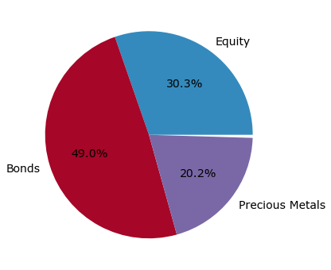

```python
# Let's see the total current asset allocation
# The small white area is the residual cash
weights = []
print('Asset allocation:\n')
for comp in (equity, bond, precious_metals):
    weights.append(find_weight(comp))
plt.figure(figsize = (8,6))
plt.pie(weights, labels = ['Equity', 'Bonds', 'Precious Metals'], autopct='%1.1f%%', textprops = {'fontsize' : 14});
```

```python
# Let's draw pie charts to represent absolute weights and relative weights for each macro asset
# (equity, bonds, precious metals)
def chart(macro_asset : str, comp1 : list, comp2: list, labels : list):
    ''' Args:
            macro_asset: equity, bonds or metals.
            comp1 : subset of tickers of the macro_asset
            comp2 : complementary subset of the same macro_asset
    '''
    fig, ax = plt.subplots(1,2, figsize = (14,5))
    fig.suptitle(macro_asset, fontsize = 26, color = 'tan', y = 1.1)
    ax[0].pie([find_weight(comp1), find_weight(comp2)], labels = labels, autopct='%1.1f%%',textprops = {'fontsize' : 13});
    ax[1].pie([find_weight(comp1) / (find_weight(comp1) + find_weight(comp2)) \
               , 1 - find_weight(comp1) / (find_weight(comp1) + find_weight(comp2))]\
              , labels = labels, autopct='%1.1f%%', textprops = {'fontsize' : 13});
    ax[0].set_title('Absolute weights')
    ax[1].set_title('Relative weights');
```

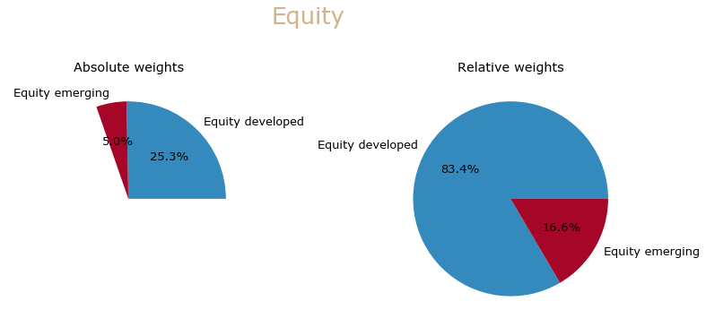

```python
macro = 'Equity'
labels = [macro + i for i in [' developed', ' emerging']]
chart(macro, equity_dev, equity_eme, labels)
```

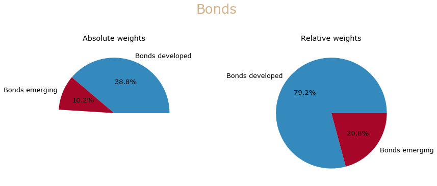

```python
macro = 'Bonds'
labels = [macro + i for i in [' developed', ' emerging']]
chart(macro, bond_dev, bond_eme, labels)
```

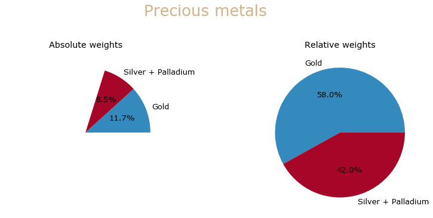

```python
labels = ['Gold', 'Silver + Palladium']
chart('Precious metals', ['SGBS'], set(precious_metals) - set(['SGBS']), labels);
```